# Final Project: Sexual Education, Pregnancy Risk, & Contraceptive Use

Author

Amel Attalla & Belen Zemas

Published

June 26, 2025

## Introduction

In this project we aim to examine the relationship between the types of sexual health education that are taught in the United States, contraceptive knowledge and risk of unplanned pregnancies, as well as how that knowledge is applied to real life. What constitutes appropriate and effective sexual education continues to be an increasingly debated topic, we aim to shed light on how different approaches-such as abstinence-only vs. contraceptive focused curricula may correlate with public health outcomes. For this project we have decided to create visualizations that focus on these three questions:

1. How does sex education type influence perceptions of pregnancy risk?

2. How does sex education type influence the method of contraceptive used?

3. How do sexual education type, perceived pregnancy risk, and contraceptive method interrelate in shaping reproductive decision-making?

## Data

We sourced our raw data set from the ICPSR website. Some of the key variables we are focusing on after cleaning the raw data are: contraceptive use, perceived risk of unplanned pregnancy, and types of sexual health education received. Cleaning the data set mainly consisted of narrowing down the variables from 340 to 12 keeping only the variables that we felt were relevant to our project/ the visualizations we wanted to make. The steps taken to wrangle and clean the original data set can be seen in it’s entirety in the code below.

```r
# Load libraries and data
library(tidyverse)
library(dplyr)
library(haven)

raw_data <- read_dta("data/Guttmacher 2009 Survey of contraceptive knowledge (Fog Zone).dta")

clean_fogzone <- raw_data %>%
  select(gender,age4grps,race,riskr,abstonly,protect,curmethrr,pregknowr,totknowr,nummthdsr,wprotect,mprotect) %>%
  rename(
    Current_most_effective_method = curmethrr,
    Pregnancy_knowledge = pregknowr,
    BC_method_knowledge = totknowr,
    BC_methods_heard_about = nummthdsr,
    Age = age4grps,
    Women_protection_status = wprotect,
    Men_protection_status = mprotect,
    Protection_status = protect
  ) %>%
  mutate(
    gender = case_when(
      gender == 1 ~ "Female",
      gender == 2 ~ "Male",
      TRUE ~ NA_character_
    ),
    race = case_when(
      race == 1 ~ "Hispanic",
      race == 2 ~ "Non-Hispanic White",
      race == 3 ~ "Non-hispanic Black",
      race == 4 ~ "Asian",
      race == 5 ~ "Other",
      TRUE ~ NA_character_
    ),
    Age = case_when(
      Age == 1 ~ "18-19",
      Age == 2 ~ "20-21",
      Age == 3 ~ "22-24",
      Age == 4 ~ "25-29",
      TRUE ~ NA_character_
    ),
    riskr = case_when(
      riskr == 1 ~ "No",
      riskr == 2 ~ "Yes",
      TRUE ~ NA_character_
    ),
    abstonly = case_when(
      abstonly == 1 ~ "Abstinence Only",
      abstonly == 2 ~ "Abstinence Focused",
      abstonly == 3 ~ "Contraceptive Focused",
      is.na(abstonly) ~ "No sex ed/ don't know",
      TRUE ~ NA_character_
    ),
    Protection_status = case_when(
      Protection_status == 1 ~ "Well protected",
      Protection_status == 2 ~ "Unprotected",
      Protection_status == 3 ~ "Uncertain status",
      Protection_status == 7 ~ "No Sex",
      TRUE ~ NA_character_
    ),
    Women_protection_status = case_when(
      Women_protection_status == 1 ~ "perfect pill use",
      Women_protection_status == 2 ~ "perfect condom use",
      Women_protection_status == 3 ~ "perfect depo use",
      Women_protection_status == 4 ~ "long-acting method",
      Women_protection_status == 5 ~ "skipped pills",
      Women_protection_status == 6 ~ "missed condom use",
      Women_protection_status == 7 ~ "depo late",
      Women_protection_status == 8 ~ "other method",
      Women_protection_status == 9 ~ "no method - likely at risk",
      Women_protection_status == 17 ~ "no method - unkown risk",
      Women_protection_status == 19 ~ "no sex ever/last 12 mo",
      TRUE ~ NA_character_
    ),
    Men_protection_status = case_when(
      Men_protection_status == 1 ~ "use horm/larc",
      Men_protection_status == 2 ~ "perfect condom use",
      Men_protection_status == 3 ~ "inconsistent condom use",
      Men_protection_status == 4 ~ "withdrawl",
      Men_protection_status == 5 ~ "other/unknown",
      Men_protection_status == 6 ~ "no method - risk likely",
      Men_protection_status == 7 ~ "no method - unknown risk",
      Men_protection_status == 8 ~ "no sex ever/ last 12 mo",
      TRUE ~ NA_character_
    ),
    Current_most_effective_method = case_when(
      Current_most_effective_method == 1 ~ "long-acting alone",
      Current_most_effective_method == 2 ~ "long-acting + condom",
      Current_most_effective_method == 3 ~ "hormonal alone",
      Current_most_effective_method == 4 ~ "hormonal + condoms",
      Current_most_effective_method == 5 ~ "condoms",
      Current_most_effective_method == 6 ~ "withdrawl/NFP",
      Current_most_effective_method == 7 ~ "other/unknown",
      Current_most_effective_method == 17 ~ "no method - risk unknown",
      Current_most_effective_method == 18 ~ "no method - likely at risk",
      Current_most_effective_method == 19 ~ "no sex ever/ last 12 mo",
      TRUE ~ NA_character_
    ),
    Pregnancy_knowledge = case_when(
      Pregnancy_knowledge == 1 ~ "0-3 correct",
      Pregnancy_knowledge == 4 ~ "4 correct",
      Pregnancy_knowledge == 5 ~ "5 correct",
      Pregnancy_knowledge == 6 ~ "6 correct",
      TRUE ~ NA_character_
    ),
    BC_method_knowledge = case_when(
      BC_method_knowledge == 1 ~ "0-7 correct",
      BC_method_knowledge == 2 ~ "8-11 correct",
      BC_method_knowledge == 3 ~ "12-15 correct",
      BC_method_knowledge == 4 ~ "16-18 correct",
      BC_method_knowledge == 5 ~ "19+ correct",
      TRUE ~ NA_character_
    ),
    BC_methods_heard_about = case_when(
      BC_methods_heard_about == 1 ~ "0-6 methods",
      BC_methods_heard_about == 2 ~ "7-10 methods",
      BC_methods_heard_about== 3 ~ "11-13 methods",
      BC_methods_heard_about == 4 ~ "14-16 methods",
      TRUE ~ NA_character_
    )
  )
```

## Visualization 1: Sexual Health Education and Risk of Unintended Pregnancy (Grouped Bar Chart)

This plot displays the percentage of participants who perceive themselves to be at risk of unintended pregnancy, grouped by the type of sexual education they received.

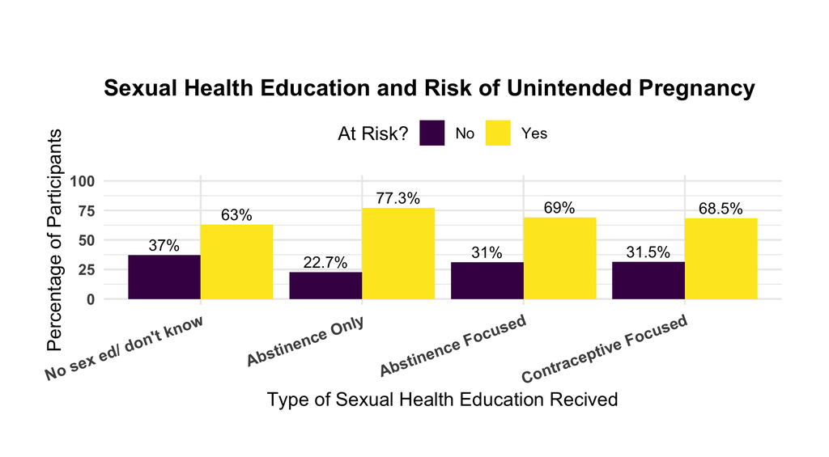

```r
# your code here
library(ggplot2)
library(viridis)
library(dplyr)

clean_fogzone <- readRDS("data/clean_fogzone.rds")


clean_fogzone_factors <- clean_fogzone %>%
  mutate(
    abstonly = factor(
      abstonly,
      levels = c("No sex ed/ don't know", "Abstinence Only", "Abstinence Focused", "Contraceptive Focused")
    ),
    riskr = factor(riskr, levels = c("No", "Yes"))
  )

percent_data <- clean_fogzone_factors %>%
  group_by(abstonly, riskr) %>%
  summarise(n=n(), .groups="drop") %>%
  group_by(abstonly) %>%
  mutate(pct = n / sum(n) * 100)

ggplot(percent_data, aes(x = abstonly, y = pct, fill = riskr)) +
  geom_bar(stat = "identity", position = position_dodge(width = 0.9)) +
  geom_text(
    aes(label = paste0(round(pct, 1), "%")),
    position = position_dodge(width = 0.9),
    vjust = -0.4,
    size = 3.5
  ) +
  scale_fill_viridis_d(
    option="D",
    name = "At Risk?",
    labels = c("No", "Yes")
  ) +
  labs(
    title = "Sexual Health Education and Risk of Unintended Pregnancy",
    x = "Type of Sexual Health Education Recived",
    y = "Percentage of Participants"
  ) +
  ylim(0,100) +
  theme_minimal(base_size = 12) +
  theme(
    plot.margin = margin(50, 30, 30, 30),  # Adjust all margins (top, right, bottom, left)
    axis.text.x = element_text(angle = 20, hjust = 1, face = "bold", size = 10),
    axis.text.y = element_text(face = "bold"),
    plot.title = element_text(face = "bold"),
    legend.position = "top"
  )
```

## Visualization 2: Contraceptive Methods by Type of Sexual Education (Faceted Bar Chart)

This plot displays the contraceptive methods used by participants grouped by their type of sex ed.

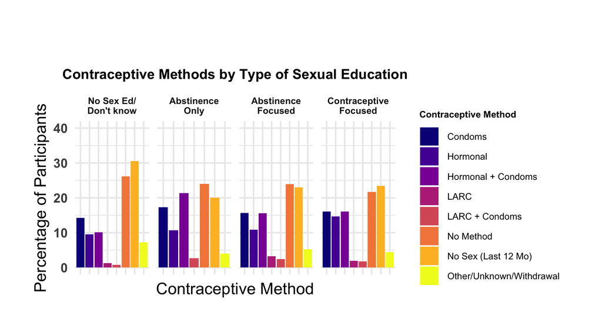

```r
contraceptive_data <- clean_fogzone_factors %>%
  filter(!is.na(Current_most_effective_method)) %>%
  mutate(
    method_grouped = case_when(
      Current_most_effective_method %in% c("no method - likely at risk", "no method - risk unknown") ~ "No method",
      Current_most_effective_method %in% c("withdrawl/NFP", "other/unknown") ~ "Other/Unknown/Withdrawal",
      TRUE ~ Current_most_effective_method
    ),

    method_grouped = recode(method_grouped,
      "condoms" = "Condoms",
      "hormonal + condoms" = "Hormonal + Condoms",
      "hormonal alone" = "Hormonal",
      "long-acting + condom" = "LARC + Condoms",
      "long-acting alone" = "LARC",
      "No method" = "No Method",
      "no sex ever/ last 12 mo" = "No Sex (Last 12 Mo)",
      "Other/Unknown/Withdrawal" = "Other/Unknown/Withdrawal"
    ),
    method_grouped = factor(method_grouped),


    abstonly = recode(abstonly,
      "No sex ed/ don't know" = "No Sex Ed/\nDon't know",
      "Abstinence Only" = "Abstinence\nOnly",
      "Abstinence Focused" = "Abstinence\nFocused",
      "Contraceptive Focused" = "Contraceptive\nFocused"
    )
  )


contraceptive_summary <- contraceptive_data %>%
  group_by(abstonly, method_grouped) %>%
  summarise(n = n(), .groups = "drop") %>%
  group_by(abstonly) %>%
  mutate(pct = n / sum(n) * 100)


ggplot(contraceptive_summary, aes(x = method_grouped, y = pct, fill = method_grouped)) +
  geom_bar(stat = "identity") +
  scale_fill_viridis_d(
    name = "Contraceptive Method",
    option = "C"
  ) +
  labs(
    title = "Contraceptive Methods by Type of Sexual Education",
    x = "Contraceptive Method",
    y = "Percentage of Participants"
  ) +
  ylim(0, 40) +
  facet_wrap(~abstonly, nrow = 1, scales = "free_x") +
  theme_minimal(base_size = 14) +
  theme(
    plot.margin = margin(t = 60, r = 30, b = 30, l = 30),
    axis.text.x = element_blank(),
    axis.ticks.x = element_blank(),
    axis.text.y = element_text(face = "bold"),
    plot.title = element_text(face = "bold", hjust = 0.5, size = 12),
    strip.text = element_text(face = "bold", size = 8),
    legend.position = "right",
    legend.title = element_text(face = "bold", size = 8),
    legend.text = element_text(size = 8)
  )
```

## Visualization 3: Flow of Sex Ed → Risk Perception → Contraceptive Method

This diagram shows the flow of participants through the type of sex ed they receive, whether they perceive pregnancy risk, and their chosen contraceptive method.

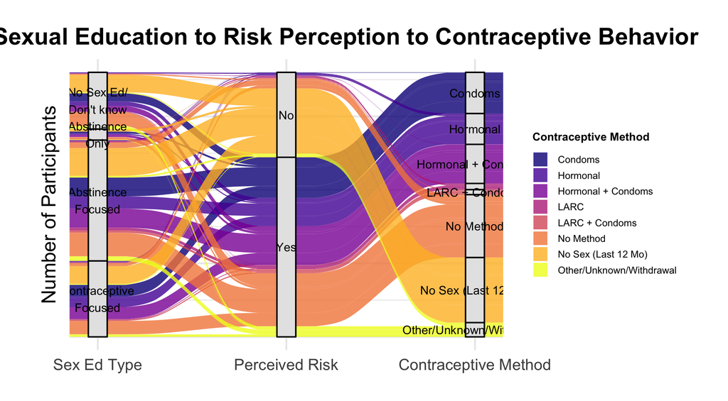

```r
library(tidyverse)
library(ggplot2)
library(ggalluvial)
library(dplyr)

sankey_data <- contraceptive_data %>%
  filter(!is.na(riskr), !is.na(abstonly), !is.na(method_grouped)) %>%
  count(abstonly, riskr, method_grouped)

ggplot(sankey_data,
       aes(axis1 = abstonly, axis2 = riskr, axis3 = method_grouped,
           y = n)) +
  geom_alluvium(aes(fill = method_grouped), width = 0.3, alpha=0.8) +
  geom_stratum(
    width = 0.1,
    fill = "gray90",
    color = "black") +
  geom_text(
    stat = "stratum",
    aes(label = after_stat(stratum)),
    size = 3,
    check_overlap =TRUE,
    na.rm = TRUE,
    label_axis3 = NULL
  ) +
  scale_x_discrete(limits = c("Sex Ed Type", "Perceived Risk", "Contraceptive Method"),
                   expand = c(0.05, 0.05)) +
  scale_fill_viridis_d(option = "C", name = "Contraceptive Method") +
  labs(
    title = "Flow from Sexual Education to Risk Perception to Contraceptive Behavior",
    y = "Number of Participants"
  ) +
  theme_minimal(base_size = 14) +
  theme(
    plot.title = element_text(face = "bold", hjust = 0.5),
    axis.text.y = element_blank(),
    axis.ticks = element_blank(),
    legend.title = element_text(size = 8, face = "bold"),
    legend.text = element_text(size = 7),
    legend.key.size = unit(0.4, "cm"),
    legend.spacing.y = unit(0.2, "cm"),
    legend.position = "right",
    plot.margin = margin(t = 20, r = 30, b = 20, l = 30)
  )
```

## Interpretation

Together, these three visualizations reveal how different types of sexual health education influence participants’ self-perception of pregnancy risk and their contraceptive behavior.

## Limitations

This data is subject to several limitations. First, all observations rely on self-reported information about sexual health knowledge and behaviors, which introduces the potential for recall bias and social desirability bias. Participants may have overestimated their safe sex practices or under-reported riskier behaviors. Second, while the dataset includes many helpful variables, it lacks information about where participants received their sexual health education. Knowing the state or region could enable geographic visualizations or an interactive Shiny app to explore the effects of state-specific curricula—an insight that could support policy arguments for more comprehensive sex education in public schools. Finally, the data was collected in 2009 and may not reflect more recent policy changes, cultural shifts, or behavioral trends among young people.

## References

1. Reference 1: Raw Data file Frost, Jennifer J. 2009 National Survey of Reproductive and Contraceptive Knowledge: Guttmacher 2009 Survey of contraceptive knowledge Fog Zone .dta. Ann Arbor, MI: Inter-university Consortium for Political and Social Research [distributor], 2022-03-31. https://doi.org/10.3886/E164142V1-146384 https://www.openicpsr.org/openicpsr/project/164142/version/V1/view?path=/openicpsr/164142/fcr:versions/V1/Guttmacher-2009-Survey-of-contraceptive-knowledge–Fog-Zone-.dta&type=file
2. Reference 2: Codebook for raw data Frost, Jennifer J. 2009 National Survey of Reproductive and Contraceptive Knowledge: Guttmacher 2009 Survey of contraceptive knowledge Fog Zone user guide and codebook.pdf. Ann Arbor, MI: Inter-university Consortium for Political and Social Research [distributor], 2022-03-31. https://doi.org/10.3886/E164142V1-131024 https://www.openicpsr.org/openicpsr/project/164142/version/V1/view?path=/openicpsr/164142/fcr:versions/V1/Guttmacher-2009-Survey-of-contraceptive-knowledge–Fog-Zone–user-guide-and-codebook.pdf&type=file#
3. Reference 3: ICPSR project link Frost, Jennifer J. 2009 National Survey of Reproductive and Contraceptive Knowledge. Ann Arbor, MI: Inter-university Consortium for Political and Social Research [distributor], 2022-03-31. https://doi.org/10.3886/E164142V1 https://www.openicpsr.org/openicpsr/project/164142/version/V1/view